# Regression analyses of MPG data

Jonathon Price

19 January 2016

# Exploratory Data Analyses

The data set contails 11 variables, output can be seen in figure 1 of appendex. From this output we can see that Transmission type is coded as a numeric, but really should be a factor. Before correcting this a correlation matrics can be generated, See figure 2 for output.

```r
cor(mtcars)
```

Correct the transmission type to a factor

```r
mtcars$am <- as.factor(mtcars$am)
levels(mtcars$am) <- c("auto", "man")
```

# Method for model selection

To answer the questions about transmision type on MPG we need to generate a model that will allow the transmission type to be evaluated while holding the other factor equal, i.e. simply comparing the mean MPG of the two transmision types is invalided as transmision type is likly confounded with other variables that influance MPG. Simple creating a model that uses all variables is also not likly the best model as with the small dataset its likly to overfit the data.

Using the correlation tabel focussing on the mpg column the wt (weight) has the highest corraltation to MPG. The next 3 values cyl, disp and hp are also high, but when checking these varables for corralation to wt it can be seen they are also highly corralated and inclustion will increase the model bias. To select futher variables the step function is used to automaticly search for the best model.

```r
mod <- lm(mpg ~ ., data = mtcars)
stepOutput <- step(mod,trace=FALSE)
stepOutput$call
```

```
## lm(formula = mpg ~ wt + qsec + am, data = mtcars)
```

From the output of steps is wt, qsec and am. To confirm the output of steps, we can compare the models `mpg ~ am` vs `mpg ~ am + wt` vs `mpg ~ am + wt + qsec` and `mpg ~ am` vs `mpg ~ am + qsec` vs `mpg ~ am + qsec + wt`

```r
fit1 <- lm(mpg ~ am, data = mtcars)
fit2 <- lm(mpg ~ wt + am , data = mtcars)
fit3 <-lm(mpg ~ wt + qsec + am, data = mtcars)
anova(fit1, fit2,fit3)
```

```
## Analysis of Variance Table
##
## Model 1: mpg ~ am
## Model 2: mpg ~ wt + am
## Model 3: mpg ~ wt + qsec + am
##   Res.Df    RSS Df Sum of Sq      F    Pr(>F)
## 1     30 720.90
## 2     29 278.32  1    442.58 73.203 2.673e-09 ***
## 3     28 169.29  1    109.03 18.034 0.0002162 ***
## ---
## Signif. codes:  0 '***' 0.001 '**' 0.01 '*' 0.05 '.' 0.1 ' ' 1
```

```r
fit1 <- lm(mpg ~ am, data = mtcars)
fit2 <- lm(mpg ~ qsec + am , data = mtcars)
fit3 <-lm(mpg ~ wt + qsec + am, data = mtcars)
anova(fit1, fit2,fit3)
```

```
## Analysis of Variance Table
##
## Model 1: mpg ~ am
## Model 2: mpg ~ qsec + am
## Model 3: mpg ~ wt + qsec + am
##   Res.Df    RSS Df Sum of Sq      F    Pr(>F)
## 1     30 720.90
## 2     29 352.63  1    368.26 60.911 1.679e-08 ***
## 3     28 169.29  1    183.35 30.326 6.953e-06 ***
## ---
## Signif. codes:  0 '***' 0.001 '**' 0.01 '*' 0.05 '.' 0.1 ' ' 1
```

In both cases we see that adding both wt and qsec had significant (P < 0.05)effect. Therefor the model that will be used to answer the MPG questions is `mpg ~ wt + qsec + am`.

# Model Elvauation

Reviewing the residuals plots see figure 3 the only things looks a bit concerning is the Residuals vs fitted plot whch may be showing a bit of Heteroskedasticity, although it dosn’t appare to be two bad and may be just an arterfact of the low sample numbers.

# Conclusion

[output not shown]

```
## [1] 0.04573031 5.82594408
```

With 95% confidence, we estimate that switching from automatic to manual while keeping weight and 1/4 second mile time the same will results in a 0.05 to 5.83 increase in MPG. Therefor given a car switching from automatic to manual, which is unlikly to effect weight or 1/4 second mile time is better for MPG, although this difference my be very small.

# Appendix

#### figure 1

```r
data("mtcars")
str(mtcars)
```

```
## 'data.frame':    32 obs. of  11 variables:
##  $ mpg : num  21 21 22.8 21.4 18.7 18.1 14.3 24.4 22.8 19.2 ...
##  $ cyl : num  6 6 4 6 8 6 8 4 4 6 ...
##  $ disp: num  160 160 108 258 360 ...
##  $ hp  : num  110 110 93 110 175 105 245 62 95 123 ...
##  $ drat: num  3.9 3.9 3.85 3.08 3.15 2.76 3.21 3.69 3.92 3.92 ...
##  $ wt  : num  2.62 2.88 2.32 3.21 3.44 ...
##  $ qsec: num  16.5 17 18.6 19.4 17 ...
##  $ vs  : num  0 0 1 1 0 1 0 1 1 1 ...
##  $ am  : num  1 1 1 0 0 0 0 0 0 0 ...
##  $ gear: num  4 4 4 3 3 3 3 4 4 4 ...
##  $ carb: num  4 4 1 1 2 1 4 2 2 4 ...
```

#### figure 2

```r
cor(mtcars)
```

```
##             mpg        cyl       disp         hp        drat         wt
## mpg   1.0000000 -0.8521620 -0.8475514 -0.7761684  0.68117191 -0.8676594
## cyl  -0.8521620  1.0000000  0.9020329  0.8324475 -0.69993811  0.7824958
## disp -0.8475514  0.9020329  1.0000000  0.7909486 -0.71021393  0.8879799
## hp   -0.7761684  0.8324475  0.7909486  1.0000000 -0.44875912  0.6587479
## drat  0.6811719 -0.6999381 -0.7102139 -0.4487591  1.00000000 -0.7124406
## wt   -0.8676594  0.7824958  0.8879799  0.6587479 -0.71244065  1.0000000
## qsec  0.4186840 -0.5912421 -0.4336979 -0.7082234  0.09120476 -0.1747159
## vs    0.6640389 -0.8108118 -0.7104159 -0.7230967  0.44027846 -0.5549157
## am    0.5998324 -0.5226070 -0.5912270 -0.2432043  0.71271113 -0.6924953
## gear  0.4802848 -0.4926866 -0.5555692 -0.1257043  0.69961013 -0.5832870
## carb -0.5509251  0.5269883  0.3949769  0.7498125 -0.09078980  0.4276059
##             qsec         vs          am       gear        carb
## mpg   0.41868403  0.6640389  0.59983243  0.4802848 -0.55092507
## cyl  -0.59124207 -0.8108118 -0.52260705 -0.4926866  0.52698829
## disp -0.43369788 -0.7104159 -0.59122704 -0.5555692  0.39497686
## hp   -0.70822339 -0.7230967 -0.24320426 -0.1257043  0.74981247
## drat  0.09120476  0.4402785  0.71271113  0.6996101 -0.09078980
## wt   -0.17471588 -0.5549157 -0.69249526 -0.5832870  0.42760594
## qsec  1.00000000  0.7445354 -0.22986086 -0.2126822 -0.65624923
## vs    0.74453544  1.0000000  0.16834512  0.2060233 -0.56960714
## am   -0.22986086  0.1683451  1.00000000  0.7940588  0.05753435
## gear -0.21268223  0.2060233  0.79405876  1.0000000  0.27407284
## carb -0.65624923 -0.5696071  0.05753435  0.2740728  1.00000000
```

```r
mtcars$am <- as.factor(mtcars$am)
levels(mtcars$am) <- c("auto", "man")
```

#### figure 3

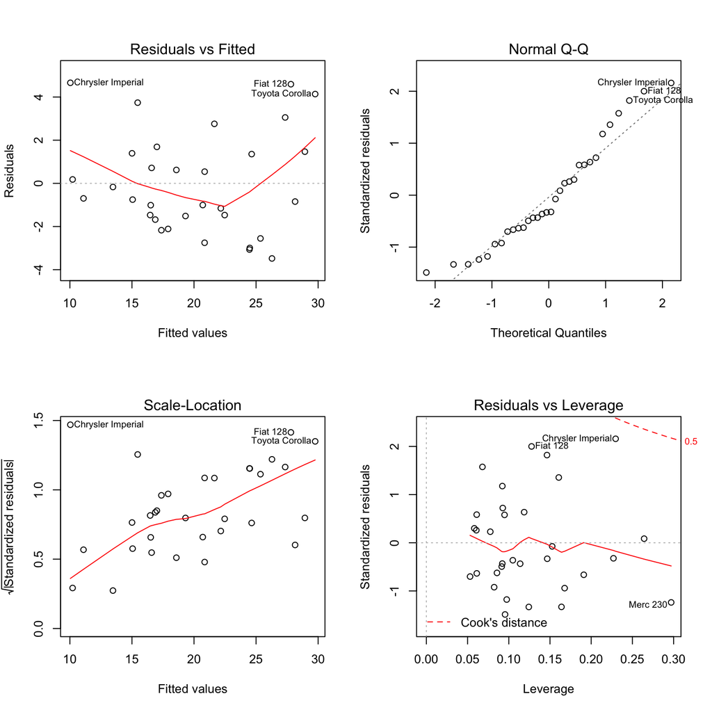